# Proyecto Final

## 1.4 Usar str() y head() para ver más detalles y ejemplos concretos

> str() nos permite ver la estructura interna de cada objeto (como tipos de datos y clases), mientras que head() muestra las primeras filas de cada tabla para tener una idea concreta del contenido.

```r
# cities
str(cities)
```

```
## spc_tbl_ [5 × 2] (S3: spec_tbl_df/tbl_df/tbl/data.frame)
##  $ id  : num [1:5] 1 2 3 4 5
##  $ city: chr [1:5] "Tel Aviv" "Ramat Gan" "Ramat Hasharon" "Herzelia" ...
##  - attr(*, "spec")=
##   .. cols(
##   ..   id = col_double(),
##   ..   city = col_character()
##   .. )
##  - attr(*, "problems")=<externalptr>
```

```r
head(cities)
```

```
## # A tibble: 5 × 2
##      id city
##   <dbl> <chr>
## 1     1 Tel Aviv
## 2     2 Ramat Gan
## 3     3 Ramat Hasharon
## 4     4 Herzelia
## 5     5 Givatayim
```

```r
# meal_types
str(meal_types)
```

```
## spc_tbl_ [4 × 2] (S3: spec_tbl_df/tbl_df/tbl/data.frame)
##  $ id       : num [1:4] 1 2 3 4
##  $ meal_type: chr [1:4] "Vegan" "Cheese" "Beef" "Chicken"
##  - attr(*, "spec")=
##   .. cols(
##   ..   id = col_double(),
##   ..   meal_type = col_character()
##   .. )
##  - attr(*, "problems")=<externalptr>
```

```r
head(meal_types)
```

```
## # A tibble: 4 × 2
##      id meal_type
##   <dbl> <chr>
## 1     1 Vegan
## 2     2 Cheese
## 3     3 Beef
## 4     4 Chicken
```

```r
# meals
str(meals)
```

```
## spc_tbl_ [350 × 7] (S3: spec_tbl_df/tbl_df/tbl/data.frame)
##  $ id           : num [1:350] 1 2 3 4 5 6 7 8 9 10 ...
##  $ restaurant_id: num [1:350] 1 1 1 1 1 1 1 1 1 1 ...
##  $ serve_type_id: num [1:350] 1 2 3 3 3 3 3 2 2 1 ...
##  $ meal_type_id : num [1:350] 2 4 1 2 2 2 2 1 2 3 ...
##  $ hot_cold     : chr [1:350] "Cold" "Hot" "Cold" "Hot" ...
##  $ meal_name    : chr [1:350] "Meal 1" "Meal 2" "Meal 3" "Meal 4" ...
##  $ price        : num [1:350] 43.2 29.2 37.3 52.4 27.8 ...
##  - attr(*, "spec")=
##   .. cols(
##   ..   id = col_double(),
##   ..   restaurant_id = col_double(),
##   ..   serve_type_id = col_double(),
##   ..   meal_type_id = col_double(),
##   ..   hot_cold = col_character(),
##   ..   meal_name = col_character(),
##   ..   price = col_double()
##   .. )
##  - attr(*, "problems")=<externalptr>
```

```r
head(meals)
```

```
## # A tibble: 6 × 7
##      id restaurant_id serve_type_id meal_type_id hot_cold meal_name price
##   <dbl>         <dbl>         <dbl>        <dbl> <chr>    <chr>     <dbl>
## 1     1             1             1            2 Cold     Meal 1     43.2
## 2     2             1             2            4 Hot      Meal 2     29.2
## 3     3             1             3            1 Cold     Meal 3     37.3
## 4     4             1             3            2 Hot      Meal 4     52.4
## 5     5             1             3            2 Cold     Meal 5     27.8
## 6     6             1             3            2 Cold     Meal 6     32.1
```

```r
# members
str(members)
```

```
## spc_tbl_ [200 × 7] (S3: spec_tbl_df/tbl_df/tbl/data.frame)
##  $ id            : num [1:200] 1 2 3 4 5 6 7 8 9 10 ...
##  $ first_name    : chr [1:200] "Ollie" "Landon" "Jia" "Valentina" ...
##  $ surname       : chr [1:200] "Kinney" "Bishop" "Delarosa" "Ratcliffe" ...
##  $ sex           : chr [1:200] "M" "F" "M" "F" ...
##  $ email         : chr [1:200] "Ol.Kinney@walla.co.il" "La.Bi@gmail.com" "Jia.De@gmail.com" "Va.Ratcliffe@gmail.com" ...
##  $ city_id       : num [1:200] 4 4 4 4 3 3 4 5 2 5 ...
##  $ monthly_budget: num [1:200] 1000 500 500 600 500 600 500 600 500 600 ...
##  - attr(*, "spec")=
##   .. cols(
##   ..   id = col_double(),
##   ..   first_name = col_character(),
##   ..   surname = col_character(),
##   ..   sex = col_character(),
##   ..   email = col_character(),
##   ..   city_id = col_double(),
##   ..   monthly_budget = col_double()
##   .. )
##  - attr(*, "problems")=<externalptr>
```

```r
head(members)
```

```
## # A tibble: 6 × 7
##      id first_name surname   sex   email                  city_id monthly_budget
##   <dbl> <chr>      <chr>     <chr> <chr>                    <dbl>          <dbl>
## 1     1 Ollie      Kinney    M     Ol.Kinney@walla.co.il        4           1000
## 2     2 Landon     Bishop    F     La.Bi@gmail.com              4            500
## 3     3 Jia        Delarosa  M     Jia.De@gmail.com             4            500
## 4     4 Valentina  Ratcliffe F     Va.Ratcliffe@gmail.com       4            600
## 5     5 Stacie     Patel     F     St.Patel@hotmail.com         3            500
## 6     6 Fallon     Case      M     Fa.Case@walla.co.il          3            600
```

```r
# monthly_member_totals
str(monthly_member_totals)
```

```
## spc_tbl_ [1,200 × 14] (S3: spec_tbl_df/tbl_df/tbl/data.frame)
##  $ member_id     : num [1:1200] 47 126 68 193 53 115 192 19 176 130 ...
##  $ first_name    : chr [1:1200] "Joyce" "Macey" "Aydin" "Mira" ...
##  $ surname       : chr [1:1200] "Newton" "Almond" "Hirst" "Kent" ...
##  $ sex           : chr [1:1200] "F" "M" "M" "M" ...
##  $ email         : chr [1:1200] "Joyce.Ne@gmail.com" "Macey.Almond@yahoo.com" "Aydin.Hirst@hotmail.com" "Mi.Kent@walla.co.il" ...
##  $ city          : chr [1:1200] "Herzelia" "Tel Aviv" "Tel Aviv" "Tel Aviv" ...
##  $ year          : num [1:1200] 2020 2020 2020 2020 2020 2020 2020 2020 2020 2020 ...
##  $ month         : num [1:1200] 1 1 1 1 1 1 1 1 1 1 ...
##  $ order_count   : num [1:1200] 17 30 24 24 23 25 21 20 21 20 ...
##  $ meals_count   : num [1:1200] 37 64 52 54 50 62 46 36 51 52 ...
##  $ monthly_budget: num [1:1200] 1836 2677 2287 2548 2457 ...
##  $ total_expense : num [1:1200] 500 1000 1000 500 1000 600 1000 1000 600 1000 ...
##  $ balance       : num [1:1200] -1336 -1677 -1287 -2048 -1457 ...
##  $ commission    : num [1:1200] 136 215 165 194 194 ...
##  - attr(*, "spec")=
##   .. cols(
##   ..   member_id = col_double(),
##   ..   first_name = col_character(),
##   ..   surname = col_character(),
##   ..   sex = col_character(),
##   ..   email = col_character(),
##   ..   city = col_character(),
##   ..   year = col_double(),
##   ..   month = col_double(),
##   ..   order_count = col_double(),
##   ..   meals_count = col_double(),
##   ..   monthly_budget = col_double(),
##   ..   total_expense = col_double(),
##   ..   balance = col_double(),
##   ..   commission = col_double()
##   .. )
##  - attr(*, "problems")=<externalptr>
```

```r
head(monthly_member_totals)
```

```
## # A tibble: 6 × 14
##   member_id first_name surname sex   email         city   year month order_count
##       <dbl> <chr>      <chr>   <chr> <chr>         <chr> <dbl> <dbl>       <dbl>
## 1        47 Joyce      Newton  F     Joyce.Ne@gma… Herz…  2020     1          17
## 2       126 Macey      Almond  M     Macey.Almond… Tel …  2020     1          30
## 3        68 Aydin      Hirst   M     Aydin.Hirst@… Tel …  2020     1          24
## 4       193 Mira       Kent    M     Mi.Kent@wall… Tel …  2020     1          24
## 5        53 Lilly-Ann  Frey    F     Li.Fr@hotmai… Tel …  2020     1          23
## 6       115 Rami       Sexton  M     Rami.Sexton@… Rama…  2020     1          25
## # ℹ 5 more variables: meals_count <dbl>, monthly_budget <dbl>,
## #   total_expense <dbl>, balance <dbl>, commission <dbl>
```

```r
# order_details
str(order_details)
```

```
## spc_tbl_ [70,577 × 3] (S3: spec_tbl_df/tbl_df/tbl/data.frame)
##  $ id      : num [1:70577] 1 2 3 4 5 6 7 8 9 10 ...
##  $ order_id: num [1:70577] 3 5 5 5 5 6 6 6 7 7 ...
##  $ meal_id : num [1:70577] 176 349 348 344 348 290 291 293 252 249 ...
##  - attr(*, "spec")=
##   .. cols(
##   ..   id = col_double(),
##   ..   order_id = col_double(),
##   ..   meal_id = col_double()
##   .. )
##  - attr(*, "problems")=<externalptr>
```

```r
head(order_details)
```

```
## # A tibble: 6 × 3
##      id order_id meal_id
##   <dbl>    <dbl>   <dbl>
## 1     1        3     176
## 2     2        5     349
## 3     3        5     348
## 4     4        5     344
## 5     5        5     348
## 6     6        6     290
```

```r
# orders
str(orders)
```

```
## spc_tbl_ [36,000 × 6] (S3: spec_tbl_df/tbl_df/tbl/data.frame)
##  $ id           : num [1:36000] 1 2 3 4 5 6 7 8 9 10 ...
##  $ date         : Date[1:36000], format: "2020-01-01" "2020-01-01" ...
##  $ hour         : 'hms' num [1:36000] 11:00:00 11:08:00 11:10:00 11:13:00 ...
##   ..- attr(*, "units")= chr "secs"
##  $ member_id    : num [1:36000] 25 122 62 171 152 166 25 95 40 149 ...
##  $ restaurant_id: num [1:36000] 6 4 16 9 30 25 21 1 30 19 ...
##  $ total_order  : num [1:36000] 0 0 39 0 153 ...
##  - attr(*, "spec")=
##   .. cols(
##   ..   id = col_double(),
##   ..   date = col_date(format = ""),
##   ..   hour = col_time(format = ""),
##   ..   member_id = col_double(),
##   ..   restaurant_id = col_double(),
##   ..   total_order = col_double()
##   .. )
##  - attr(*, "problems")=<externalptr>
```

```r
head(orders)
```

```
## # A tibble: 6 × 6
##      id date       hour   member_id restaurant_id total_order
##   <dbl> <date>     <time>     <dbl>         <dbl>       <dbl>
## 1     1 2020-01-01 11:00         25             6          0
## 2     2 2020-01-01 11:08        122             4          0
## 3     3 2020-01-01 11:10         62            16         39
## 4     4 2020-01-01 11:13        171             9          0
## 5     5 2020-01-01 11:13        152            30        153
## 6     6 2020-01-01 11:13        166            25        120.
```

```r
# restaurant_types
str(restaurant_types)
```

```
## spc_tbl_ [5 × 2] (S3: spec_tbl_df/tbl_df/tbl/data.frame)
##  $ id             : num [1:5] 1 2 3 4 5
##  $ restaurant_type: chr [1:5] "Fast Food" "Asian" "Italian" "Homemade" ...
##  - attr(*, "spec")=
##   .. cols(
##   ..   id = col_double(),
##   ..   restaurant_type = col_character()
##   .. )
##  - attr(*, "problems")=<externalptr>
```

```r
head(restaurant_types)
```

```
## # A tibble: 5 × 2
##      id restaurant_type
##   <dbl> <chr>
## 1     1 Fast Food
## 2     2 Asian
## 3     3 Italian
## 4     4 Homemade
## 5     5 Indian
```

```r
# restaurants
str(restaurants)
```

```
## spc_tbl_ [30 × 5] (S3: spec_tbl_df/tbl_df/tbl/data.frame)
##  $ id                : num [1:30] 1 2 3 4 5 6 7 8 9 10 ...
##  $ restaurant_name   : chr [1:30] "Restaurant 1" "Restaurant 2" "Restaurant 3" "Restaurant 4" ...
##  $ restaurant_type_id: num [1:30] 3 5 2 4 5 1 1 2 1 4 ...
##  $ income_persentage : num [1:30] 0.075 0.1 0.075 0.1 0.05 0.05 0.1 0.075 0.075 0.1 ...
##  $ city_id           : num [1:30] 3 3 4 4 2 2 4 5 4 2 ...
##  - attr(*, "spec")=
##   .. cols(
##   ..   id = col_double(),
##   ..   restaurant_name = col_character(),
##   ..   restaurant_type_id = col_double(),
##   ..   income_persentage = col_double(),
##   ..   city_id = col_double()
##   .. )
##  - attr(*, "problems")=<externalptr>
```

```r
head(restaurants)
```

```
## # A tibble: 6 × 5
##      id restaurant_name restaurant_type_id income_persentage city_id
##   <dbl> <chr>                        <dbl>             <dbl>   <dbl>
## 1     1 Restaurant 1                     3             0.075       3
## 2     2 Restaurant 2                     5             0.1         3
## 3     3 Restaurant 3                     2             0.075       4
## 4     4 Restaurant 4                     4             0.1         4
## 5     5 Restaurant 5                     5             0.05        2
## 6     6 Restaurant 6                     1             0.05        2
```

```r
# serve_types
str(serve_types)
```

```
## spc_tbl_ [3 × 2] (S3: spec_tbl_df/tbl_df/tbl/data.frame)
##  $ id        : num [1:3] 1 2 3
##  $ serve_type: chr [1:3] "Starter" "Main" "Desert"
##  - attr(*, "spec")=
##   .. cols(
##   ..   id = col_double(),
##   ..   serve_type = col_character()
##   .. )
##  - attr(*, "problems")=<externalptr>
```

```r
head(serve_types)
```

```
## # A tibble: 3 × 2
##      id serve_type
##   <dbl> <chr>
## 1     1 Starter
## 2     2 Main
## 3     3 Desert
```

# 2 Transformando los datos

## 2.1 Convertir la columna sex en factor en members y renombrar niveles

> En esta sección trabajamos con el dataset de miembros (members) para transformar la columna sex en un factor con niveles más legibles: “Femenino” y “Masculino”.

```r
# Convert 'sex' to factor and rename levels
members <- members %>%
  mutate(sex = factor(sex, levels = c("F", "M"), labels = c("Femenino", "Masculino")))
```

## 2.2 Transformar hot_cold en factor en meals y aplicar orden (“cold” < “hot”)

> Aquí usamos la columna hot_cold del dataset meals, que indica si la comida es caliente o fría, y la convertimos en un factor ordenado.

```r
# Convert 'hot_cold' to ordered factor with "cold" < "hot"
meals <- meals %>%
  mutate(hot_cold = factor(hot_cold, levels = c("cold", "hot"), ordered = TRUE))

# Validate order comparison
"cold" < "hot"  # This returns TRUE if the order was applied correctly
```

```
## [1] TRUE
```

## 2.3 Transformar columnas en monthly_member_totals y crear nueva columna

> En este paso, trabajamos con monthly_member_totals. Convertimos sex y month a factores con etiquetas descriptivas, y luego creamos una nueva columna que calcula la proporción de órdenes respecto al número de comidas.

```r
# Transform 'sex' and 'month' to labeled factors and create 'order_meal_ratio'
monthly_member_totals <- monthly_member_totals %>%
  mutate(
    sex = factor(sex, levels = c("F", "M"), labels = c("Femenino", "Masculino")),
    month = factor(month, levels = c("1", "2", "3", "4", "5"),
                          labels = c("Enero", "Febrero", "Marzo", "Abril", "Mayo")),
    order_meal_ratio = order_count / meals_count
  )
```

## 2.4 Imprimir la variable modificada con la nueva columna

> Finalmente imprimimos el dataset transformado para verificar que los cambios se hayan aplicado correctamente.

```r
# Print transformed data with new column
glimpse(monthly_member_totals)
```

```
## Rows: 1,200
## Columns: 15
## $ member_id        <dbl> 47, 126, 68, 193, 53, 115, 192, 19, 176, 130, 195, 19…
## $ first_name       <chr> "Joyce", "Macey", "Aydin", "Mira", "Lilly-Ann", "Rami…
## $ surname          <chr> "Newton", "Almond", "Hirst", "Kent", "Frey", "Sexton"…
## $ sex              <fct> Femenino, Masculino, Masculino, Masculino, Femenino, …
## $ email            <chr> "Joyce.Ne@gmail.com", "Macey.Almond@yahoo.com", "Aydi…
## $ city             <chr> "Herzelia", "Tel Aviv", "Tel Aviv", "Tel Aviv", "Tel …
## $ year             <dbl> 2020, 2020, 2020, 2020, 2020, 2020, 2020, 2020, 2020,…
## $ month            <fct> Enero, Enero, Enero, Enero, Enero, Enero, Enero, Ener…
## $ order_count      <dbl> 17, 30, 24, 24, 23, 25, 21, 20, 21, 20, 25, 29, 22, 2…
## $ meals_count      <dbl> 37, 64, 52, 54, 50, 62, 46, 36, 51, 52, 56, 65, 38, 5…
## $ monthly_budget   <dbl> 1836.15, 2676.98, 2286.53, 2547.62, 2456.64, 2760.23,…
## $ total_expense    <dbl> 500, 1000, 1000, 500, 1000, 600, 1000, 1000, 600, 100…
## $ balance          <dbl> -1336.15, -1676.98, -1286.53, -2047.62, -1456.64, -21…
## $ commission       <dbl> 136.2795, 214.9850, 164.9385, 193.5912, 193.9765, 211…
## $ order_meal_ratio <dbl> 0.4594595, 0.4687500, 0.4615385, 0.4444444, 0.4600000…
```

```r
head(monthly_member_totals)
```

```
## # A tibble: 6 × 15
##   member_id first_name surname sex       email     city   year month order_count
##       <dbl> <chr>      <chr>   <fct>     <chr>     <chr> <dbl> <fct>       <dbl>
## 1        47 Joyce      Newton  Femenino  Joyce.Ne… Herz…  2020 Enero          17
## 2       126 Macey      Almond  Masculino Macey.Al… Tel …  2020 Enero          30
## 3        68 Aydin      Hirst   Masculino Aydin.Hi… Tel …  2020 Enero          24
## 4       193 Mira       Kent    Masculino Mi.Kent@… Tel …  2020 Enero          24
## 5        53 Lilly-Ann  Frey    Femenino  Li.Fr@ho… Tel …  2020 Enero          23
## 6       115 Rami       Sexton  Masculino Rami.Sex… Rama…  2020 Enero          25
## # ℹ 6 more variables: meals_count <dbl>, monthly_budget <dbl>,
## #   total_expense <dbl>, balance <dbl>, commission <dbl>,
## #   order_meal_ratio <dbl>
```

```r
print(monthly_member_totals)
```

```
## # A tibble: 1,200 × 15
##    member_id first_name surname  sex       email   city   year month order_count
##        <dbl> <chr>      <chr>    <fct>     <chr>   <chr> <dbl> <fct>       <dbl>
##  1        47 Joyce      Newton   Femenino  Joyce.… Herz…  2020 Enero          17
##  2       126 Macey      Almond   Masculino Macey.… Tel …  2020 Enero          30
##  3        68 Aydin      Hirst    Masculino Aydin.… Tel …  2020 Enero          24
##  4       193 Mira       Kent     Masculino Mi.Ken… Tel …  2020 Enero          24
##  5        53 Lilly-Ann  Frey     Femenino  Li.Fr@… Tel …  2020 Enero          23
##  6       115 Rami       Sexton   Masculino Rami.S… Rama…  2020 Enero          25
##  7       192 Amrit      Haworth  Masculino Am.Ha@… Giva…  2020 Enero          21
##  8        19 Nico       Hastings Masculino Ni.Has… Giva…  2020 Enero          20
##  9       176 Amman      Zavala   Femenino  Am.Zav… Giva…  2020 Enero          21
## 10       130 Haleemah   Davidson Femenino  Haleem… Tel …  2020 Enero          20
## # ℹ 1,190 more rows
## # ℹ 6 more variables: meals_count <dbl>, monthly_budget <dbl>,
## #   total_expense <dbl>, balance <dbl>, commission <dbl>,
## #   order_meal_ratio <dbl>
```

# 3 Comportamiento de los datos

**Evaluando tendencias lineales**

## 3.1 Graficar la proporción order_count / meals_count como línea

> Creamos una gráfica lineal usando ggplot para visualizar la columna order_meal_ratio a través de los meses.

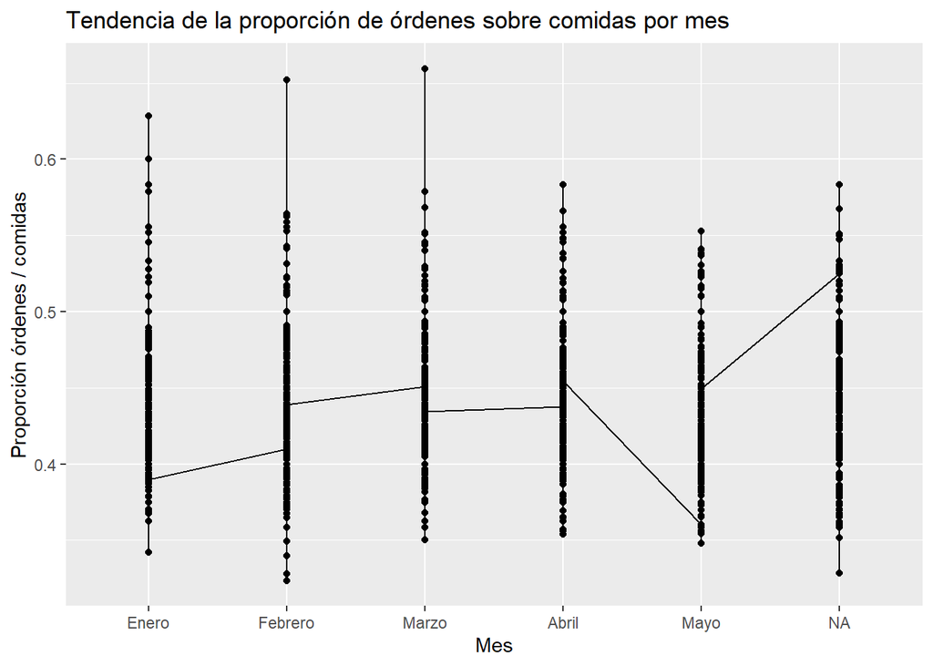

```r
# Line plot: order_meal_ratio vs. month without color aesthetics
ggplot(monthly_member_totals, aes(x = month, y = order_meal_ratio, group = 1)) +
  geom_line() +
  geom_point() +
  labs(
    title = "Tendencia de la proporción de órdenes sobre comidas por mes",
    x = "Mes",
    y = "Proporción órdenes / comidas"
  )
```

## 3.2 Usar color en la variable month para diferenciar en la gráfica

> Ahora aplicamos color a la variable month para que se diferencien los puntos y líneas en la visualización.

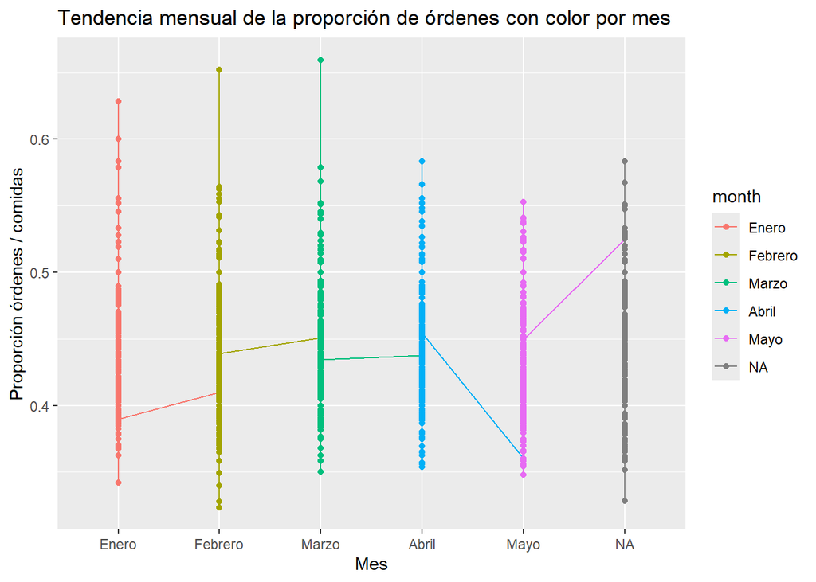

```r
# Line plot with month as color aesthetic
ggplot(monthly_member_totals, aes(x = month, y = order_meal_ratio, color = month, group = 1)) +
  geom_line() +
  geom_point() +
  labs(
    title = "Tendencia mensual de la proporción de órdenes con color por mes",
    x = "Mes",
    y = "Proporción órdenes / comidas"
  )
```

*Relación, selección y ordenamiento de datos*

## 3.3 Identificar los archivos a unir

> Se trabajará con los siguientes archivos:
- cities.csv
- members.csv
- orders.csv
- restaurants.csv

## 3.4 Usar inner_join() para construir las relaciones correspondientes

> Se combinan los datasets orders, members, cities (dos veces) y restaurants. Esto permite acceder tanto a la ciudad del cliente como a la del restaurante.

```r
# Join orders with members, cities, and restaurants (including restaurant city)
member_orders_joined <- orders %>%
  inner_join(members, by = c("member_id" = "id"), suffix = c(".order", ".member")) %>%
  inner_join(cities, by = c("city_id" = "id"), suffix = c(".member", ".city")) %>%
  inner_join(restaurants, by = c("restaurant_id" = "id"), suffix = c(".member", ".restaurant")) %>%
  inner_join(cities, by = c("city_id.restaurant" = "id"), suffix = c(".member", ".restaurant"))
```

## 3.5 Usar select() para mostrar los campos especificados

> Seleccionamos los campos solicitados: datos personales, ciudad del miembro, fecha, hora y datos del restaurante.

```r
# Select required fields from the joined data
member_orders_selected <- member_orders_joined %>%
  select(
    first_name,
    surname,
    sex,
    email,
    city_member = city.member,
    date,
    hour,
    total_order,
    restaurant_name,
    city_restaurant = city.restaurant
  )
```

## 3.6 Ordenar ascendentemente por total_order

```r
# Sort the selected data by total_order in ascending order
member_orders_sorted <- member_orders_selected %>%
  arrange(total_order)
```

## 3.7 Imprimir el resultado ordenado

```r
# Print the first few rows of the sorted and selected data
print(member_orders_sorted)
```

```
## # A tibble: 36,000 × 10
##    first_name surname   sex       email city_member date       hour  total_order
##    <chr>      <chr>     <fct>     <chr> <chr>       <date>     <tim>       <dbl>
##  1 Safwan     Flowers   Masculino Sa.F… Tel Aviv    2020-01-01 11:00           0
##  2 Ellena     Castro    Femenino  El.C… Herzelia    2020-01-01 11:08           0
##  3 Hanna      Shelton   Femenino  Hann… Givatayim   2020-01-01 11:13           0
##  4 Mairead    Acevedo   Femenino  Ma.A… Herzelia    2020-01-01 11:19           0
##  5 Princess   Timms     Femenino  Pr.T… Tel Aviv    2020-01-01 11:29           0
##  6 Parker     Drake     Masculino Park… Ramat Hash… 2020-01-01 11:36           0
##  7 Armaan     Weston    Masculino Ar.W… Tel Aviv    2020-01-01 11:37           0
##  8 Terrence   Payne     Masculino Te.P… Tel Aviv    2020-01-01 11:51           0
##  9 Emaan      Greenaway Masculino Emaa… Herzelia    2020-01-01 11:59           0
## 10 Luka       Holder    Femenino  Luka… Givatayim   2020-01-01 12:05           0
## # ℹ 35,990 more rows
## # ℹ 2 more variables: restaurant_name <chr>, city_restaurant <chr>
```